# Optimal Treatment Analysis

## Outcome Variable

**Outcome Variable:** ever_stunted

## Predictor Variables

**Intervention Variable:** exclfeed6

**Adjustment Set:**

- arm
- sex
- W_mage
- meducyrs
- feducyrs
- hhwealth_quart
- hfoodsec
- W_mhtcm
- vagbrth
- W_gagebrth
- W_birthwt
- W_birthlen
- W_nrooms
- W_nchldlt5
- month
- brthmon
- W_parity
- impfloor
- impsan
- safeh20
- delta_W_mage
- delta_meducyrs
- delta_feducyrs
- delta_hhwealth_quart
- delta_hfoodsec
- delta_W_mhtcm
- delta_vagbrth
- delta_W_gagebrth
- delta_W_birthwt
- delta_W_birthlen
- delta_W_nrooms
- delta_W_nchldlt5
- delta_month
- delta_brthmon
- delta_W_parity
- delta_impfloor
- delta_impsan
- delta_safeh20

## Stratifying Variables

The analysis was stratified on these variable(s):

- agecat
- studyid
- country

## Data Summary

| agecat | studyid | country | exclfeed6 | ever_stunted | n_cell | n |
| --- | --- | --- | --- | --- | --- | --- |
| 0-24 months (no birth st.) | ki0047075b-MAL-ED | BANGLADESH | 0 | 0 | 71 | 198 |
| 0-24 months (no birth st.) | ki0047075b-MAL-ED | BANGLADESH | 0 | 1 | 79 | 198 |
| 0-24 months (no birth st.) | ki0047075b-MAL-ED | BANGLADESH | 1 | 0 | 20 | 198 |
| 0-24 months (no birth st.) | ki0047075b-MAL-ED | BANGLADESH | 1 | 1 | 28 | 198 |
| 0-24 months (no birth st.) | ki0047075b-MAL-ED | BRAZIL | 0 | 0 | 150 | 191 |
| 0-24 months (no birth st.) | ki0047075b-MAL-ED | BRAZIL | 0 | 1 | 27 | 191 |
| 0-24 months (no birth st.) | ki0047075b-MAL-ED | BRAZIL | 1 | 0 | 13 | 191 |
| 0-24 months (no birth st.) | ki0047075b-MAL-ED | BRAZIL | 1 | 1 | 1 | 191 |
| 0-24 months (no birth st.) | ki0047075b-MAL-ED | INDIA | 0 | 0 | 86 | 194 |
| 0-24 months (no birth st.) | ki0047075b-MAL-ED | INDIA | 0 | 1 | 105 | 194 |
| 0-24 months (no birth st.) | ki0047075b-MAL-ED | INDIA | 1 | 0 | 2 | 194 |
| 0-24 months (no birth st.) | ki0047075b-MAL-ED | INDIA | 1 | 1 | 1 | 194 |
| 0-24 months (no birth st.) | ki0047075b-MAL-ED | NEPAL | 0 | 0 | 143 | 208 |
| 0-24 months (no birth st.) | ki0047075b-MAL-ED | NEPAL | 0 | 1 | 50 | 208 |
| 0-24 months (no birth st.) | ki0047075b-MAL-ED | NEPAL | 1 | 0 | 11 | 208 |
| 0-24 months (no birth st.) | ki0047075b-MAL-ED | NEPAL | 1 | 1 | 4 | 208 |
| 0-24 months (no birth st.) | ki0047075b-MAL-ED | PERU | 0 | 0 | 90 | 238 |
| 0-24 months (no birth st.) | ki0047075b-MAL-ED | PERU | 0 | 1 | 139 | 238 |
| 0-24 months (no birth st.) | ki0047075b-MAL-ED | PERU | 1 | 0 | 2 | 238 |
| 0-24 months (no birth st.) | ki0047075b-MAL-ED | PERU | 1 | 1 | 7 | 238 |
| 0-24 months (no birth st.) | ki0047075b-MAL-ED | SOUTH AFRICA | 0 | 0 | 96 | 222 |
| 0-24 months (no birth st.) | ki0047075b-MAL-ED | SOUTH AFRICA | 0 | 1 | 126 | 222 |
| 0-24 months (no birth st.) | ki0047075b-MAL-ED | SOUTH AFRICA | 1 | 0 | 0 | 222 |
| 0-24 months (no birth st.) | ki0047075b-MAL-ED | SOUTH AFRICA | 1 | 1 | 0 | 222 |
| 0-24 months (no birth st.) | ki0047075b-MAL-ED | TANZANIA, UNITED REPUBLIC OF | 0 | 0 | 35 | 210 |
| 0-24 months (no birth st.) | ki0047075b-MAL-ED | TANZANIA, UNITED REPUBLIC OF | 0 | 1 | 174 | 210 |
| 0-24 months (no birth st.) | ki0047075b-MAL-ED | TANZANIA, UNITED REPUBLIC OF | 1 | 0 | 0 | 210 |
| 0-24 months (no birth st.) | ki0047075b-MAL-ED | TANZANIA, UNITED REPUBLIC OF | 1 | 1 | 1 | 210 |
| 0-24 months (no birth st.) | ki1000108-CMC-V-BCS-2002 | INDIA | 0 | 0 | 0 | 14 |
| 0-24 months (no birth st.) | ki1000108-CMC-V-BCS-2002 | INDIA | 0 | 1 | 0 | 14 |

[output cut: 186 more lines]

The following strata were considered:

- agecat: 0-24 months (no birth st.), studyid: ki0047075b-MAL-ED, country: BANGLADESH
- agecat: 0-24 months (no birth st.), studyid: ki0047075b-MAL-ED, country: BRAZIL
- agecat: 0-24 months (no birth st.), studyid: ki0047075b-MAL-ED, country: INDIA
- agecat: 0-24 months (no birth st.), studyid: ki0047075b-MAL-ED, country: NEPAL
- agecat: 0-24 months (no birth st.), studyid: ki0047075b-MAL-ED, country: PERU
- agecat: 0-24 months (no birth st.), studyid: ki0047075b-MAL-ED, country: SOUTH AFRICA
- agecat: 0-24 months (no birth st.), studyid: ki0047075b-MAL-ED, country: TANZANIA, UNITED REPUBLIC OF
- agecat: 0-24 months (no birth st.), studyid: ki1000108-CMC-V-BCS-2002, country: INDIA
- agecat: 0-24 months (no birth st.), studyid: ki1000108-IRC, country: INDIA
- agecat: 0-24 months (no birth st.), studyid: ki1000109-EE, country: PAKISTAN
- agecat: 0-24 months (no birth st.), studyid: ki1000304b-SAS-CompFeed, country: INDIA
- agecat: 0-24 months (no birth st.), studyid: ki1000304b-SAS-FoodSuppl, country: INDIA
- agecat: 0-24 months (no birth st.), studyid: ki1017093b-PROVIDE, country: BANGLADESH
- agecat: 0-24 months (no birth st.), studyid: ki1101329-Keneba, country: GAMBIA
- agecat: 0-24 months (no birth st.), studyid: ki1113344-GMS-Nepal, country: NEPAL
- agecat: 0-24 months (no birth st.), studyid: ki1148112-LCNI-5, country: MALAWI
- agecat: 0-24 months (no birth st.), studyid: kiGH5241-JiVitA-3, country: BANGLADESH
- agecat: 0-24 months (no birth st.), studyid: kiGH5241-JiVitA-4, country: BANGLADESH
- agecat: 0-6 months (no birth st.), studyid: ki0047075b-MAL-ED, country: BANGLADESH
- agecat: 0-6 months (no birth st.), studyid: ki0047075b-MAL-ED, country: BRAZIL
- agecat: 0-6 months (no birth st.), studyid: ki0047075b-MAL-ED, country: INDIA
- agecat: 0-6 months (no birth st.), studyid: ki0047075b-MAL-ED, country: NEPAL
- agecat: 0-6 months (no birth st.), studyid: ki0047075b-MAL-ED, country: PERU
- agecat: 0-6 months (no birth st.), studyid: ki0047075b-MAL-ED, country: SOUTH AFRICA
- agecat: 0-6 months (no birth st.), studyid: ki0047075b-MAL-ED, country: TANZANIA, UNITED REPUBLIC OF
- agecat: 0-6 months (no birth st.), studyid: ki1000108-CMC-V-BCS-2002, country: INDIA
- agecat: 0-6 months (no birth st.), studyid: ki1000108-IRC, country: INDIA
- agecat: 0-6 months (no birth st.), studyid: ki1000109-EE, country: PAKISTAN
- agecat: 0-6 months (no birth st.), studyid: ki1000304b-SAS-CompFeed, country: INDIA
- agecat: 0-6 months (no birth st.), studyid: ki1000304b-SAS-FoodSuppl, country: INDIA
- agecat: 0-6 months (no birth st.), studyid: ki1017093b-PROVIDE, country: BANGLADESH
- agecat: 0-6 months (no birth st.), studyid: ki1101329-Keneba, country: GAMBIA
- agecat: 0-6 months (no birth st.), studyid: ki1113344-GMS-Nepal, country: NEPAL
- agecat: 0-6 months (no birth st.), studyid: ki1148112-LCNI-5, country: MALAWI
- agecat: 0-6 months (no birth st.), studyid: kiGH5241-JiVitA-3, country: BANGLADESH
- agecat: 0-6 months (no birth st.), studyid: kiGH5241-JiVitA-4, country: BANGLADESH
- agecat: 6-24 months, studyid: ki0047075b-MAL-ED, country: BANGLADESH
- agecat: 6-24 months, studyid: ki0047075b-MAL-ED, country: BRAZIL
- agecat: 6-24 months, studyid: ki0047075b-MAL-ED, country: INDIA
- agecat: 6-24 months, studyid: ki0047075b-MAL-ED, country: NEPAL
- agecat: 6-24 months, studyid: ki0047075b-MAL-ED, country: PERU
- agecat: 6-24 months, studyid: ki0047075b-MAL-ED, country: SOUTH AFRICA
- agecat: 6-24 months, studyid: ki0047075b-MAL-ED, country: TANZANIA, UNITED REPUBLIC OF
- agecat: 6-24 months, studyid: ki1000108-CMC-V-BCS-2002, country: INDIA
- agecat: 6-24 months, studyid: ki1000108-IRC, country: INDIA
- agecat: 6-24 months, studyid: ki1000109-EE, country: PAKISTAN
- agecat: 6-24 months, studyid: ki1000304b-SAS-CompFeed, country: INDIA
- agecat: 6-24 months, studyid: ki1000304b-SAS-FoodSuppl, country: INDIA
- agecat: 6-24 months, studyid: ki1017093b-PROVIDE, country: BANGLADESH
- agecat: 6-24 months, studyid: ki1101329-Keneba, country: GAMBIA
- agecat: 6-24 months, studyid: ki1113344-GMS-Nepal, country: NEPAL
- agecat: 6-24 months, studyid: ki1148112-LCNI-5, country: MALAWI
- agecat: 6-24 months, studyid: kiGH5241-JiVitA-3, country: BANGLADESH
- agecat: 6-24 months, studyid: kiGH5241-JiVitA-4, country: BANGLADESH

### Dropped Strata

Some strata were dropped due to rare outcomes:

- agecat: 0-24 months (no birth st.), studyid: ki0047075b-MAL-ED, country: BRAZIL
- agecat: 0-24 months (no birth st.), studyid: ki0047075b-MAL-ED, country: INDIA
- agecat: 0-24 months (no birth st.), studyid: ki0047075b-MAL-ED, country: NEPAL
- agecat: 0-24 months (no birth st.), studyid: ki0047075b-MAL-ED, country: PERU
- agecat: 0-24 months (no birth st.), studyid: ki0047075b-MAL-ED, country: SOUTH AFRICA
- agecat: 0-24 months (no birth st.), studyid: ki0047075b-MAL-ED, country: TANZANIA, UNITED REPUBLIC OF
- agecat: 0-24 months (no birth st.), studyid: ki1000108-CMC-V-BCS-2002, country: INDIA
- agecat: 0-24 months (no birth st.), studyid: ki1000108-IRC, country: INDIA
- agecat: 0-24 months (no birth st.), studyid: ki1000304b-SAS-FoodSuppl, country: INDIA
- agecat: 0-6 months (no birth st.), studyid: ki0047075b-MAL-ED, country: BRAZIL
- agecat: 0-6 months (no birth st.), studyid: ki0047075b-MAL-ED, country: INDIA
- agecat: 0-6 months (no birth st.), studyid: ki0047075b-MAL-ED, country: NEPAL
- agecat: 0-6 months (no birth st.), studyid: ki0047075b-MAL-ED, country: PERU
- agecat: 0-6 months (no birth st.), studyid: ki0047075b-MAL-ED, country: SOUTH AFRICA
- agecat: 0-6 months (no birth st.), studyid: ki0047075b-MAL-ED, country: TANZANIA, UNITED REPUBLIC OF
- agecat: 0-6 months (no birth st.), studyid: ki1000108-CMC-V-BCS-2002, country: INDIA
- agecat: 0-6 months (no birth st.), studyid: ki1000108-IRC, country: INDIA
- agecat: 0-6 months (no birth st.), studyid: ki1000304b-SAS-FoodSuppl, country: INDIA
- agecat: 0-6 months (no birth st.), studyid: ki1148112-LCNI-5, country: MALAWI
- agecat: 6-24 months, studyid: ki0047075b-MAL-ED, country: BRAZIL
- agecat: 6-24 months, studyid: ki0047075b-MAL-ED, country: INDIA
- agecat: 6-24 months, studyid: ki0047075b-MAL-ED, country: NEPAL
- agecat: 6-24 months, studyid: ki0047075b-MAL-ED, country: PERU
- agecat: 6-24 months, studyid: ki0047075b-MAL-ED, country: SOUTH AFRICA
- agecat: 6-24 months, studyid: ki0047075b-MAL-ED, country: TANZANIA, UNITED REPUBLIC OF
- agecat: 6-24 months, studyid: ki1000108-CMC-V-BCS-2002, country: INDIA
- agecat: 6-24 months, studyid: ki1000108-IRC, country: INDIA
- agecat: 6-24 months, studyid: ki1000304b-SAS-CompFeed, country: INDIA
- agecat: 6-24 months, studyid: ki1000304b-SAS-FoodSuppl, country: INDIA

## Methods Detail

We’re interested in the causal parameters $E[Y_a]$ for all values of $a \in \mathcal{A}$. These parameters represent the mean outcome if, possibly contrary to fact, we intervened to set all units to have $A=a$. Under the randomization and positivity assumptions, these are identified by the statistical parameters $\psi_a=E_W[E_{Y|A,W}(Y|A=a,W)]$. In addition, we’re interested in the mean of $Y$, $E[Y]$ under no intervention (the observed mean). We will estimate these parameters by using SuperLearner to fit the relevant likelihood factors – $E_{Y|A,W}(Y|A=a,W)$ and $p(A=a|W)$, and then updating our likelihood fit using a joint TMLE.

For unadjusted analyses ($W=\{\}$), initial likelihoods were estimated using Lrnr_glm to estimate the simple $E(Y|A)$ and Lrnr_mean to estimate $p(A)$. For adjusted analyses, a small library containing Lrnr_glmnet, Lrnr_xgboost, and Lrnr_mean was used.

Having estimated these parameters, we will then use the delta method to estimate relative risks and attributable risks relative to a prespecified baseline level of $A$.

# Results Detail

## Results Plots

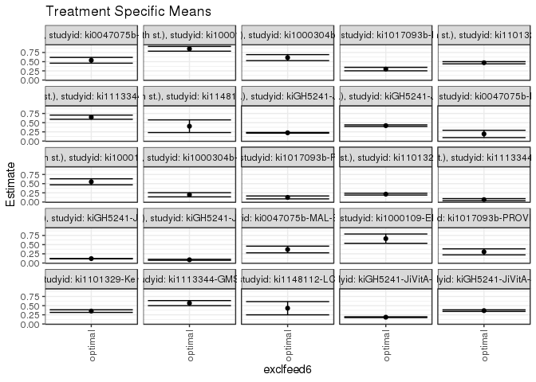

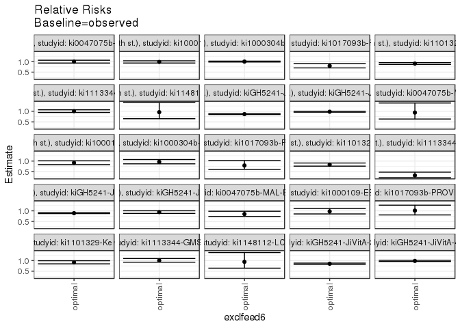

## Results Table

### Parameter: TSM

| agecat | studyid | country | intervention_level | baseline_level | estimate | ci_lower | ci_upper |
| --- | --- | --- | --- | --- | --- | --- | --- |
| 0-24 months (no birth st.) | ki0047075b-MAL-ED | BANGLADESH | optimal | NA | 0.5379806 | 0.4596828 | 0.6162785 |
| 0-24 months (no birth st.) | ki1000109-EE | PAKISTAN | optimal | NA | 0.8507280 | 0.7862600 | 0.9151960 |
| 0-24 months (no birth st.) | ki1000304b-SAS-CompFeed | INDIA | optimal | NA | 0.6105507 | 0.5290880 | 0.6920134 |
| 0-24 months (no birth st.) | ki1017093b-PROVIDE | BANGLADESH | optimal | NA | 0.2987753 | 0.2513889 | 0.3461617 |
| 0-24 months (no birth st.) | ki1101329-Keneba | GAMBIA | optimal | NA | 0.4708701 | 0.4408316 | 0.5009086 |
| 0-24 months (no birth st.) | ki1113344-GMS-Nepal | NEPAL | optimal | NA | 0.6486525 | 0.5919201 | 0.7053849 |
| 0-24 months (no birth st.) | ki1148112-LCNI-5 | MALAWI | optimal | NA | 0.4030843 | 0.2307837 | 0.5753849 |
| 0-24 months (no birth st.) | kiGH5241-JiVitA-3 | BANGLADESH | optimal | NA | 0.2242734 | 0.2156142 | 0.2329326 |
| 0-24 months (no birth st.) | kiGH5241-JiVitA-4 | BANGLADESH | optimal | NA | 0.4185472 | 0.3967794 | 0.4403150 |
| 0-6 months (no birth st.) | ki0047075b-MAL-ED | BANGLADESH | optimal | NA | 0.1932725 | 0.0935915 | 0.2929534 |
| 0-6 months (no birth st.) | ki1000109-EE | PAKISTAN | optimal | NA | 0.5504677 | 0.4688526 | 0.6320827 |
| 0-6 months (no birth st.) | ki1000304b-SAS-CompFeed | INDIA | optimal | NA | 0.1975051 | 0.1407225 | 0.2542876 |
| 0-6 months (no birth st.) | ki1017093b-PROVIDE | BANGLADESH | optimal | NA | 0.1251217 | 0.0855876 | 0.1646558 |
| 0-6 months (no birth st.) | ki1101329-Keneba | GAMBIA | optimal | NA | 0.2141591 | 0.1896054 | 0.2387127 |
| 0-6 months (no birth st.) | ki1113344-GMS-Nepal | NEPAL | optimal | NA | 0.0643884 | 0.0362788 | 0.0924980 |
| 0-6 months (no birth st.) | kiGH5241-JiVitA-3 | BANGLADESH | optimal | NA | 0.1195265 | 0.1134881 | 0.1255649 |
| 0-6 months (no birth st.) | kiGH5241-JiVitA-4 | BANGLADESH | optimal | NA | 0.0873380 | 0.0740986 | 0.1005775 |
| 6-24 months | ki0047075b-MAL-ED | BANGLADESH | optimal | NA | 0.3679220 | 0.2769095 | 0.4589346 |
| 6-24 months | ki1000109-EE | PAKISTAN | optimal | NA | 0.6628450 | 0.5357939 | 0.7898962 |
| 6-24 months | ki1017093b-PROVIDE | BANGLADESH | optimal | NA | 0.3037714 | 0.2224064 | 0.3851364 |
| 6-24 months | ki1101329-Keneba | GAMBIA | optimal | NA | 0.3511773 | 0.3157060 | 0.3866486 |
| 6-24 months | ki1113344-GMS-Nepal | NEPAL | optimal | NA | 0.5686602 | 0.4999153 | 0.6374051 |
| 6-24 months | ki1148112-LCNI-5 | MALAWI | optimal | NA | 0.4294863 | 0.2492239 | 0.6097487 |
| 6-24 months | kiGH5241-JiVitA-3 | BANGLADESH | optimal | NA | 0.1848837 | 0.1740586 | 0.1957089 |
| 6-24 months | kiGH5241-JiVitA-4 | BANGLADESH | optimal | NA | 0.3638414 | 0.3419838 | 0.3856991 |

### Parameter: E(Y)

| agecat | studyid | country | intervention_level | baseline_level | estimate | ci_lower | ci_upper |
| --- | --- | --- | --- | --- | --- | --- | --- |
| 0-24 months (no birth st.) | ki0047075b-MAL-ED | BANGLADESH | observed | NA | 0.5423451 | 0.4727526 | 0.6119375 |
| 0-24 months (no birth st.) | ki1000109-EE | PAKISTAN | observed | NA | 0.8679348 | 0.8257354 | 0.9101343 |
| 0-24 months (no birth st.) | ki1000304b-SAS-CompFeed | INDIA | observed | NA | 0.6124594 | 0.5275928 | 0.6973260 |
| 0-24 months (no birth st.) | ki1017093b-PROVIDE | BANGLADESH | observed | NA | 0.3761122 | 0.3383904 | 0.4138341 |
| 0-24 months (no birth st.) | ki1101329-Keneba | GAMBIA | observed | NA | 0.5220384 | 0.5002659 | 0.5438108 |
| 0-24 months (no birth st.) | ki1113344-GMS-Nepal | NEPAL | observed | NA | 0.6446960 | 0.6027456 | 0.6866465 |
| 0-24 months (no birth st.) | ki1148112-LCNI-5 | MALAWI | observed | NA | 0.4204754 | 0.3470727 | 0.4938781 |
| 0-24 months (no birth st.) | kiGH5241-JiVitA-3 | BANGLADESH | observed | NA | 0.2587388 | 0.2508100 | 0.2666676 |
| 0-24 months (no birth st.) | kiGH5241-JiVitA-4 | BANGLADESH | observed | NA | 0.4276154 | 0.4075359 | 0.4476948 |
| 0-6 months (no birth st.) | ki0047075b-MAL-ED | BANGLADESH | observed | NA | 0.2056209 | 0.1490372 | 0.2622046 |
| 0-6 months (no birth st.) | ki1000109-EE | PAKISTAN | observed | NA | 0.6004164 | 0.5395068 | 0.6613261 |
| 0-6 months (no birth st.) | ki1000304b-SAS-CompFeed | INDIA | observed | NA | 0.2048887 | 0.1379210 | 0.2718563 |
| 0-6 months (no birth st.) | ki1017093b-PROVIDE | BANGLADESH | observed | NA | 0.1582342 | 0.1297253 | 0.1867432 |
| 0-6 months (no birth st.) | ki1101329-Keneba | GAMBIA | observed | NA | 0.2578615 | 0.2388378 | 0.2768852 |
| 0-6 months (no birth st.) | ki1113344-GMS-Nepal | NEPAL | observed | NA | 0.1992280 | 0.1643256 | 0.2341305 |
| 0-6 months (no birth st.) | kiGH5241-JiVitA-3 | BANGLADESH | observed | NA | 0.1343282 | 0.1286356 | 0.1400209 |
| 0-6 months (no birth st.) | kiGH5241-JiVitA-4 | BANGLADESH | observed | NA | 0.0930892 | 0.0811063 | 0.1050721 |
| 6-24 months | ki0047075b-MAL-ED | BANGLADESH | observed | NA | 0.4336903 | 0.3552761 | 0.5121046 |
| 6-24 months | ki1000109-EE | PAKISTAN | observed | NA | 0.6816918 | 0.5884107 | 0.7749729 |
| 6-24 months | ki1017093b-PROVIDE | BANGLADESH | observed | NA | 0.3004677 | 0.2584159 | 0.3425195 |
| 6-24 months | ki1101329-Keneba | GAMBIA | observed | NA | 0.3829478 | 0.3575461 | 0.4083494 |
| 6-24 months | ki1113344-GMS-Nepal | NEPAL | observed | NA | 0.5646921 | 0.5158542 | 0.6135300 |
| 6-24 months | ki1148112-LCNI-5 | MALAWI | observed | NA | 0.4558569 | 0.3789125 | 0.5328014 |
| 6-24 months | kiGH5241-JiVitA-3 | BANGLADESH | observed | NA | 0.2172505 | 0.2077938 | 0.2267072 |
| 6-24 months | kiGH5241-JiVitA-4 | BANGLADESH | observed | NA | 0.3694541 | 0.3490274 | 0.3898808 |

### Parameter: RR

| agecat | studyid | country | intervention_level | baseline_level | estimate | ci_lower | ci_upper |
| --- | --- | --- | --- | --- | --- | --- | --- |
| 0-24 months (no birth st.) | ki0047075b-MAL-ED | BANGLADESH | optimal | observed | 0.9919527 | 0.9278733 | 1.0604574 |
| 0-24 months (no birth st.) | ki1000109-EE | PAKISTAN | optimal | observed | 0.9801750 | 0.9294549 | 1.0336629 |
| 0-24 months (no birth st.) | ki1000304b-SAS-CompFeed | INDIA | optimal | observed | 0.9968835 | 0.9766684 | 1.0175171 |
| 0-24 months (no birth st.) | ki1017093b-PROVIDE | BANGLADESH | optimal | observed | 0.7943780 | 0.6994619 | 0.9021742 |
| 0-24 months (no birth st.) | ki1101329-Keneba | GAMBIA | optimal | observed | 0.9019837 | 0.8597269 | 0.9463175 |
| 0-24 months (no birth st.) | ki1113344-GMS-Nepal | NEPAL | optimal | observed | 1.0061370 | 0.9459337 | 1.0701718 |
| 0-24 months (no birth st.) | ki1148112-LCNI-5 | MALAWI | optimal | observed | 0.9586393 | 0.6501467 | 1.4135108 |
| 0-24 months (no birth st.) | kiGH5241-JiVitA-3 | BANGLADESH | optimal | observed | 0.8667946 | 0.8487913 | 0.8851799 |
| 0-24 months (no birth st.) | kiGH5241-JiVitA-4 | BANGLADESH | optimal | observed | 0.9787937 | 0.9579420 | 1.0000992 |
| 0-6 months (no birth st.) | ki0047075b-MAL-ED | BANGLADESH | optimal | observed | 0.9399455 | 0.6355824 | 1.3900600 |
| 0-6 months (no birth st.) | ki1000109-EE | PAKISTAN | optimal | observed | 0.9168098 | 0.8310454 | 1.0114250 |
| 0-6 months (no birth st.) | ki1000304b-SAS-CompFeed | INDIA | optimal | observed | 0.9639628 | 0.8681546 | 1.0703443 |
| 0-6 months (no birth st.) | ki1017093b-PROVIDE | BANGLADESH | optimal | observed | 0.7907374 | 0.6102468 | 1.0246112 |
| 0-6 months (no birth st.) | ki1101329-Keneba | GAMBIA | optimal | observed | 0.8305197 | 0.7603667 | 0.9071452 |
| 0-6 months (no birth st.) | ki1113344-GMS-Nepal | NEPAL | optimal | observed | 0.3231895 | 0.2194910 | 0.4758802 |
| 0-6 months (no birth st.) | kiGH5241-JiVitA-3 | BANGLADESH | optimal | observed | 0.8898092 | 0.8700953 | 0.9099697 |
| 0-6 months (no birth st.) | kiGH5241-JiVitA-4 | BANGLADESH | optimal | observed | 0.9382186 | 0.8785219 | 1.0019717 |
| 6-24 months | ki0047075b-MAL-ED | BANGLADESH | optimal | observed | 0.8483520 | 0.7344609 | 0.9799038 |
| 6-24 months | ki1000109-EE | PAKISTAN | optimal | observed | 0.9723529 | 0.8533907 | 1.1078985 |
| 6-24 months | ki1017093b-PROVIDE | BANGLADESH | optimal | observed | 1.0109952 | 0.8067268 | 1.2669856 |
| 6-24 months | ki1101329-Keneba | GAMBIA | optimal | observed | 0.9170371 | 0.8471195 | 0.9927253 |
| 6-24 months | ki1113344-GMS-Nepal | NEPAL | optimal | observed | 1.0070270 | 0.9239672 | 1.0975533 |
| 6-24 months | ki1148112-LCNI-5 | MALAWI | optimal | observed | 0.9421515 | 0.6438265 | 1.3787090 |
| 6-24 months | kiGH5241-JiVitA-3 | BANGLADESH | optimal | observed | 0.8510162 | 0.8221153 | 0.8809331 |
| 6-24 months | kiGH5241-JiVitA-4 | BANGLADESH | optimal | observed | 0.9848082 | 0.9586517 | 1.0116785 |